# Item/User Based Collaborative Filtering using Recommender Lab

# 1 Data

```r
library(recommenderlab)

data("MovieLense")

head(as(MovieLense[1,], "list")[[1]])
```

```
                                    Toy Story (1995)
                                                   5
                                    GoldenEye (1995)
                                                   3
                                   Four Rooms (1995)
                                                   4
                                   Get Shorty (1995)
                                                   3
                                      Copycat (1995)
                                                   3
Shanghai Triad (Yao a yao yao dao waipo qiao) (1995)
                                                   5
```

Additionally, we can visualize this matrix by plotting the items on the x-axis, the users on the y-axis and assigning a color value to the rating. As we can see, this is a very sparse matrix, meaning that most users did not rate most things.

## 1.1 Matrix Visualization

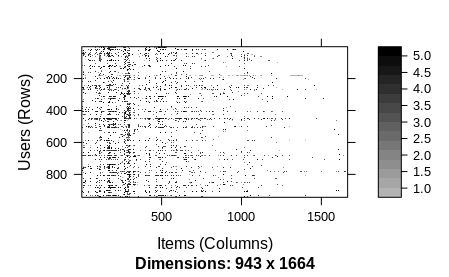

```r
mtx <- MovieLense

image(mtx)
```

In fact, we can examine this closer. Below, we look at the histograms of row and column counts. We can see the [long tail](http://infolab.stanford.edu/~ullman/mmds/ch9.pdf) that’s discussed in the link course text.

## 1.2 Rating Distribution

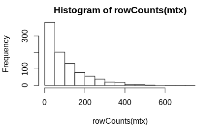

```r
hist(rowCounts(mtx))
```

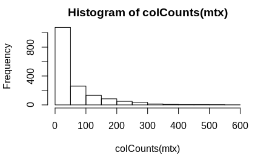

```r
hist(colCounts(mtx))
```

Below, we see that the mean rating is 3.6. This means that the average movie is better than the 2.5 we would expect. Either these viewers are optimistic or they tend to watch movies that they think they will enjoy.

## 1.3 Average Rating

```r
mean(rowMeans(mtx))
```

```
[1] 3.587565
```

## 1.4 Test/Train Split

Next, I split the data into test and train sets using the above mentioned package. I used a split of 70% training and 30% testing in an attempt to minimize overfitting but still have reliable prediction measurements.

```r
set.seed(1)
idx <- evaluationScheme(mtx, method = "split", train = .7, k = 1, given = 15)
idx
```

```
Evaluation scheme with 15 items given
Method: ‘split’ with 1 run(s).
Training set proportion: 0.700
Good ratings: NA
Data set: 943 x 1664 rating matrix of class ‘realRatingMatrix’ with 99392 ratings.
```

# 2 User-based collaborative Filtering

## 2.1 Cosine Similarity

User-based collaborative filtering relies on the assumptions that different people have similar tastes. That is, if Alice and Bob like a large proportion of the same movies, then Bob and Alice’s scores are more likely to be the same on movies one or the other hasn’t seen (but the other has). The main disadvantage of this is the huge amount of data required to find each ‘type’ of user.

The first model I built uses cosine similarity which measures the angles between two vectors. Two orthogonal vectors will have a score of 0 (because they are unrelated) and two parallel vectors will have a score of 1 (because they are effectively the same). This technique comes from the dot product but excludes the magnitude term because that’s largely dependent on the number of ratings (which varies between users).

```r
model1 <- Recommender(getData(idx, "train"), method = "UBCF",
                     parameter = list(method = "cosine"))
recommendations1 <- predict(model1, getData(idx, "known"), type = "ratings")
pred1 <- calcPredictionAccuracy(recommendations1, getData(idx, "unknown"))
```

## 2.2 Pearson Similarity

Model two uses the [Pearson correlation coefficient](https://pdfs.semanticscholar.org/1453/171acb23daae8e4075dc741dc21c6ad89800.pdf), which is defined as

which is also the covariance of the variables divided by the product of their standard deviations.

```r
model2 <- Recommender(getData(idx, "train"), method = "UBCF",
                     parameter = list(method = "Pearson"))
recommendations2 <- predict(model2, getData(idx, "known"), type = "ratings")
pred2 <- calcPredictionAccuracy(recommendations2, getData(idx, "unknown"))
```

## 2.3 Jaccard Similarity

The third model we evaluate for UBCF uses Jaccard similarity. It’s a measure of the intersection of two users divided by their union. It’s defined mathematically as

```r
model3 <- Recommender(getData(idx, "train"), method = "UBCF",
                     parameter = list(method = "jaccard"))
recommendations3 <- predict(model3, getData(idx, "known"), type = "ratings")
pred3 <- calcPredictionAccuracy(recommendations3, getData(idx, "unknown"))
```

# 3 Item based collaborative filtering

Like user-based filtering, we use the similarities between items to find new items that a user might like. Similar to the above process, we test each similarity method with our data, in the same order.

## 3.1 Cosine Similarity

In this section, I build a model that users item-based collaborative filtering with cosine similarity.

```r
model4 <- Recommender(getData(idx, "train"), method = "IBCF",
                     parameter = list(method = "cosine"))
recommendations4 <- predict(model4, getData(idx, "known"), type = "ratings")
pred4 <- calcPredictionAccuracy(recommendations4, getData(idx, "unknown"))
```

## 3.2 Pearson Similarity

In this section, I build a model that users item-based collaborative filtering with Pearson similarity.

```r
model5 <- Recommender(getData(idx, "train"), method = "IBCF",
                     parameter = list(method = "Pearson"))
recommendations5 <- predict(model5, getData(idx, "known"), type = "ratings")
pred5 <- calcPredictionAccuracy(recommendations5, getData(idx, "unknown"))
```

## 3.3 Jaccard Similarity

In this section, I build a model that users item-based collaborative filtering with Jaccard similarity.

```r
model6 <- Recommender(getData(idx, "train"), method = "IBCF",
                     parameter = list(method = "jaccard"))
recommendations6 <- predict(model6, getData(idx, "known"), type = "ratings")
pred6 <- calcPredictionAccuracy(recommendations6, getData(idx, "unknown"))
```

# 4 Conclusion

```r
preds <- rbind(pred1, pred2, pred3, pred4, pred5, pred6)
preds <- as.data.frame(preds)
row.names(preds) <- c("UBCF cosine", "UBCF Pearson", "UBCF Jaccard", "IBCF cosine", "IBCF Pearson", "IBCF Jaccard")
preds
```

[output not shown]